# Assignment 4

Pruthvi(CE16B034)

20 Febraury 2019

# Question 1

A binary source generates digits 1 and 0 randomly with probabilities 0.6 and 0.4, respectively. (a). What is the probability that two 1’s and three 0’s will occur in a five-digit sequence?

```r
# We need a binomial distribution with p = 0.6(prob of digit 1)
# We need two 1's out of total 5 digits
dbinom(2,5,0.6)
```

```
## [1] 0.2304
```

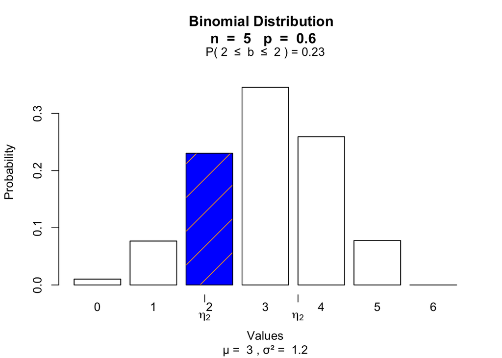

```r
# visualization
library(visualize)
# we use the visualize.binom to visualize the calculated above probability
visualize.binom(c(2,2),5,0.6,section = "bounded",strict=c(F,F))
```

(b). What is the probability that at least three 1’s will occur in a five-digit sequence?

```r
# We use pbinom because we need cumulative probability until three 1's with probabilities as above
pbinom(3,5,0.6)
```

```
## [1] 0.66304
```

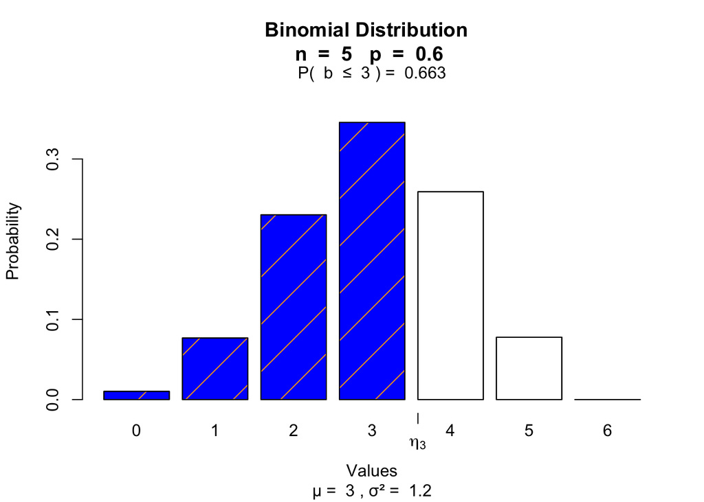

```r
# we use the visualize.binom to visualize the calculated above probability
visualize.binom(3,5,0.6,section = "lower")
```

# Question 2

Consider an experiment of tossing a fair coin repeatedly until the coin lands heads the sixth time. Find the probability that it takes exactly 10 tosses.

```r
# we need negative binomial distribution with 4 tails and total heads = 6
# i.e. prob that we get 4 tails until we get 6 heads
dnbinom(4,6,0.5)
```

```
## [1] 0.1230469
```

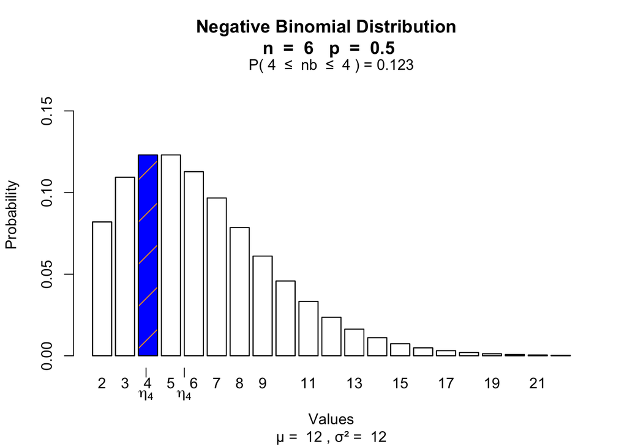

```r
# visualize the above probability
visualize.nbinom(c(4,4),6,0.5,section = "bounded",strict = c(F,F))
```

# Question 3

An experiment consists of observing the sum of the dice when two fair dice are thrown. (a). Find the probability that the sum is 7.

```r
# load the required libraries
library(prob,quietly = T,verbose = F,warn.conflicts = F,logical.return = F)
# We create sample space such that 2 dice have been rolled
S <- rolldie(2,6,makespace = T)
# Prob that we get a sum of 7 from both the dice
Prob(S,(X1+X2)==7)
```

```
## [1] 0.1666667
```

(b). Find the probability that it will take less than six tosses to throw a 7.

```r
# from above question, the prob we get sum of 7 is 1/6. So in this question required probability is geometric with p = 1/6
# We need less than 6 tosses => in 5 tossess, 5th toss is required 7 and remaining 4 are failures
# We use pgeom because we need cumulative prob, until 4 failures are recorded
pgeom(4,1/6)
```

```
## [1] 0.5981224
```

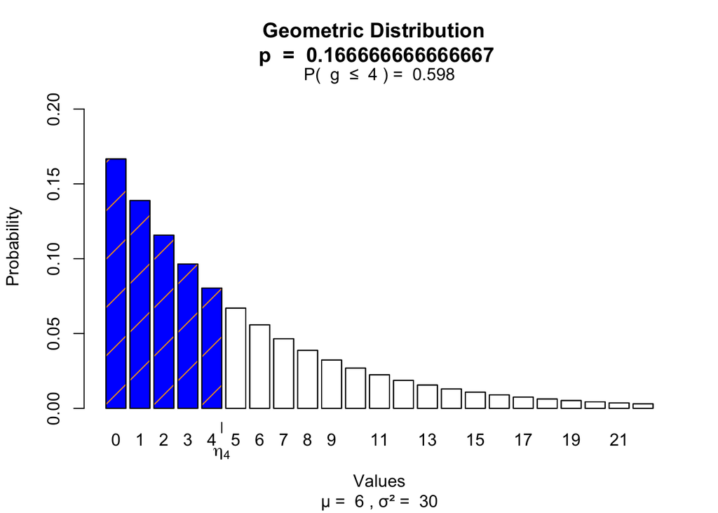

```r
# visualize the above probability
visualize.geom(4,1/6)
```

(c). Find the probability that it will take more than six tosses to throw a 7.

```r
# We need more than 6 tosses => We need more than 5 failures and one success
# => P(Failures > 5,prob of success = 1/6)
pgeom(5,1/6,lower.tail = F)
```

```
## [1] 0.334898
```

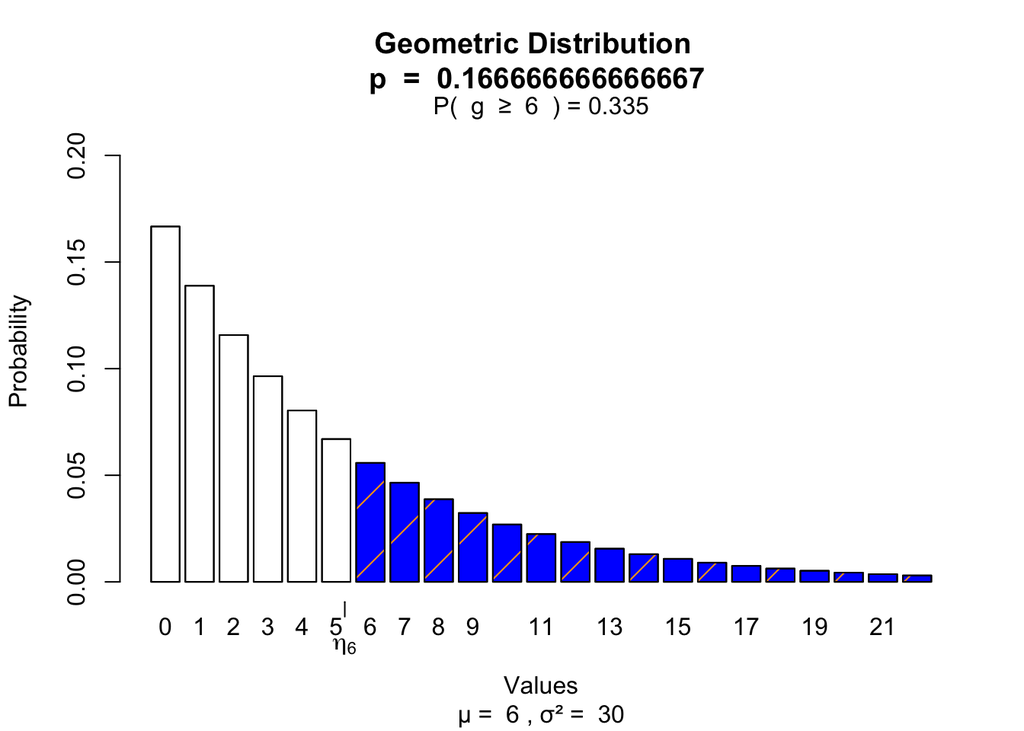

```r
# visualize the above probability
visualize.geom(6,1/6,section = "upper")
```

# Question 4

Let X be a normal distribution with mean 15 and variance 16.Find (a).P(9 <= X <= 18)

```r
# = P(X<=18) - P(X<=9)
# mean = 15 and standard deviation = 4
pnorm(18,15,4) - pnorm(9,15,4)
```

```
## [1] 0.7065654
```

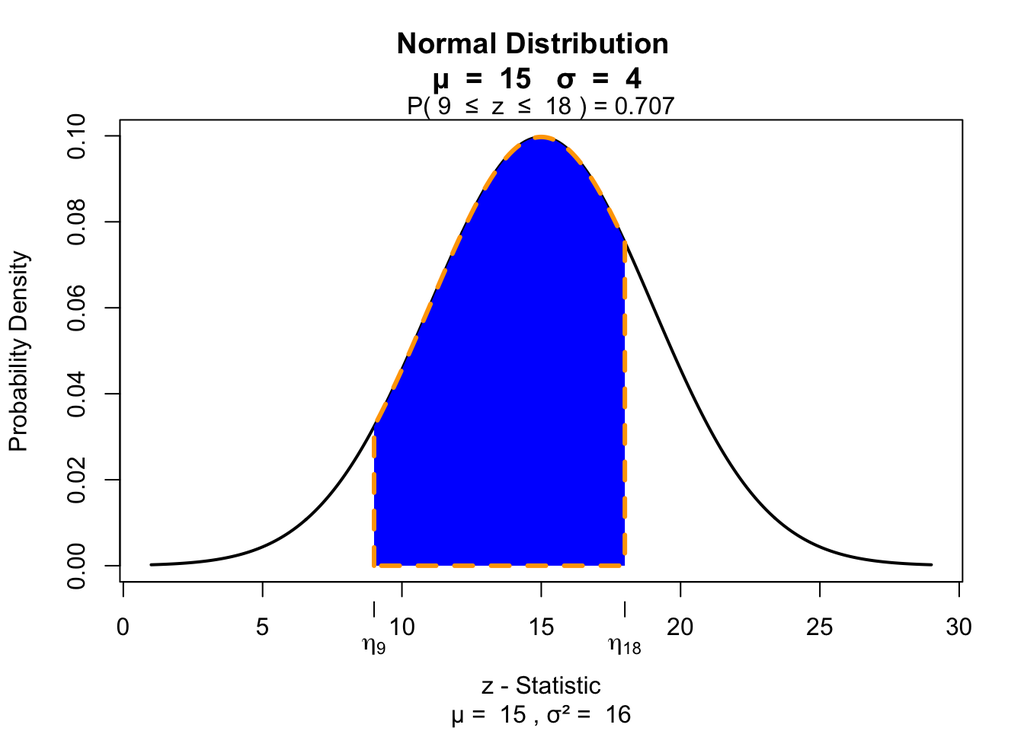

```r
# visualize the above probability
visualize.norm(c(9,18),15,4,section = "bounded")
```

(b).P(9 <= X <= 18|X <= 15)

```r
# = P(9 <= X <= 15) / P(X <= 15)
(pnorm(15,15,4)-pnorm(9,15,4)) / pnorm(15,15,4)
```

```
## [1] 0.8663856
```

(c).P(|X - 15| >= 0.6)

```r
# = P(14.4 <= X <= 15.6)
pnorm(15.6,15,4) - pnorm(14.4,15,4)
```

```
## [1] 0.1192354
```

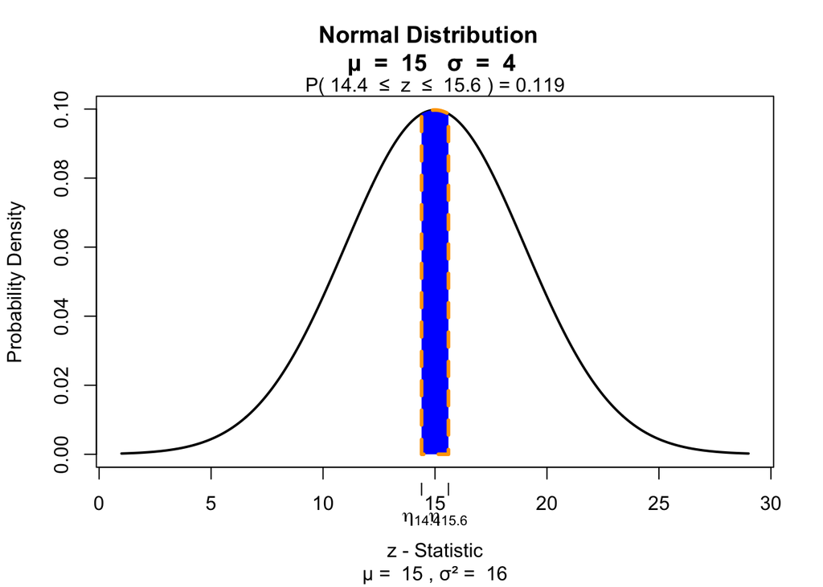

```r
#  visualize the above probability
visualize.norm(c(14.4,15.6),15,4,section = "bounded")
```

# Question 5

Let X be a normal distribution with mean -1 and variance 9. (a). Find x such that P(X > x) = 0.42

```r
# P(X <= x) = 1 - 0.42 = 0.58
qnorm(0.58,-1,3)
```

```
## [1] -0.3943196
```

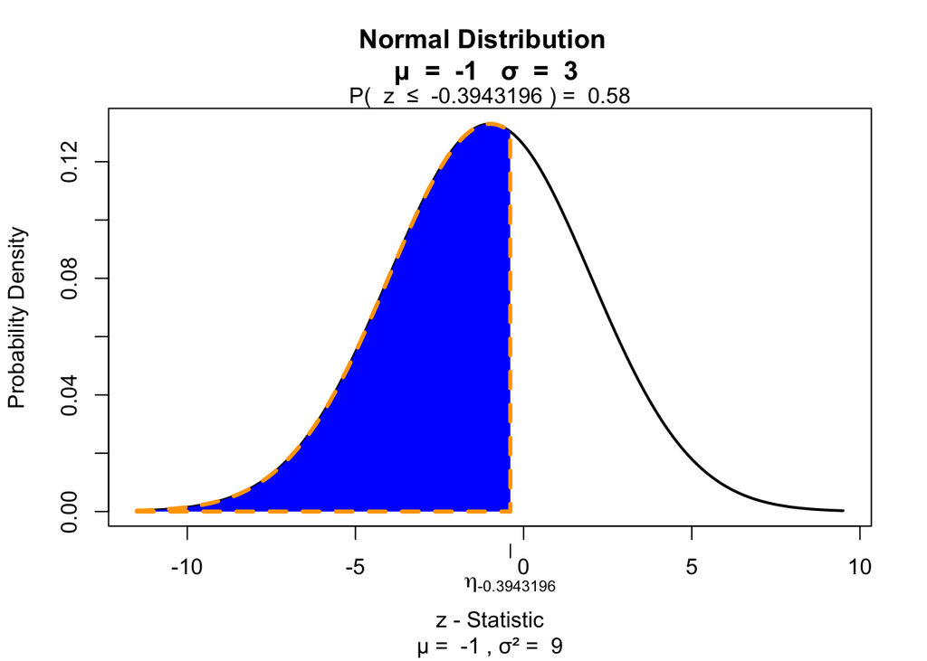

```r
# visualize the above probability
# -0.3943196 we got from above question
visualize.norm(-0.3943196,-1,3)
```

(b). Find x such that P(|X + 1| < x) = 0.45

```r
# = P(-x < X+1 < x) = P(-x/3 < (X + 1)/3 < x/3) ~ stdnorm
# = 2 * P(x/3) - 1
# => (0.45+1) / 2 is the probability for which we have to find the z value (std norm)
qnorm(1.45/2,0,1) * 3
```

```
## [1] 1.79328
```

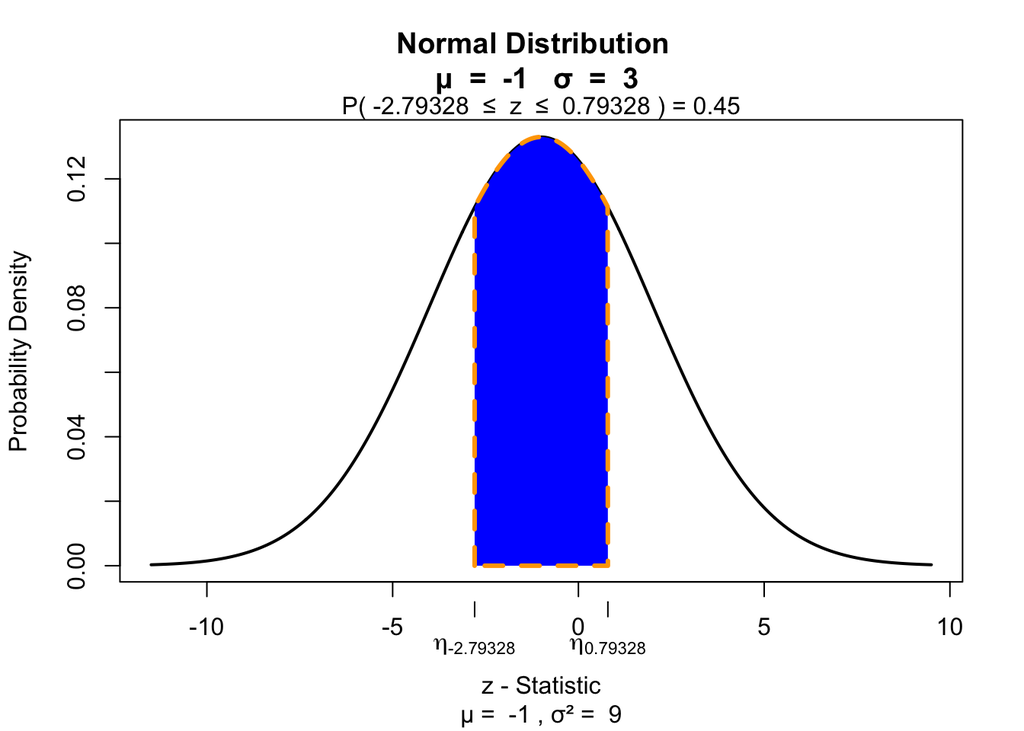

```r
# visualize
visualize.norm(c(-2.79328,0.79328),-1,3,section = "bounded")
```